# Birth Death Process

StA 2060A - Stochastic Processes

2024-03-14

## Realization of a Yule Furry process

We obtain a realization of a Yule Furry process with $X(0) = 1$ and birth rate $\lambda$ as 0.20 and 0.35, when it is observed for t = 10 time units.

### Part I: Input birth rates, X(0)and t

```r
la=c(0.20,0.35);a=1;t=10
```

### Part II: Realizations

```r
int=x=arr=u=v=w=list(); N=c()
for(j in 1:length(la))
{
set.seed(j)
y=s=c();sumy=0; i=1;s[1]=a
while(sumy<t)
{
y[i]=rexp(1,rate=s[i]*la[j])
s[i+1]=s[i]+1
sumy=sum(y)
i=i+1
}
int[[j]]=y[-length(y)]
N[j]=length(int[[j]])
x[[j]]=s[-length(s)]
u[[j]]=rep(x[[j]],each=2)
arr[[j]]=round(cumsum(int[[j]]),2)
v[[j]]=c(0,round(rep(arr[[j]],each=2),3),t)
w[[j]]=c(0,arr[[j]])
}
N
```

```
## [1]  6 13
```

```r
list("States"=x,"Interval r.v."=int,"Birth epochs"=arr)
```

```
## $States
## $States[[1]]
## [1] 1 2 3 4 5 6 7
##
## $States[[2]]
##  [1]  1  2  3  4  5  6  7  8  9 10 11 12 13 14
##
##
## $`Interval r.v.`
## $`Interval r.v.`[[1]]
## [1] 3.7759092 2.9541069 0.2428445 0.1747441 0.4360686 2.4124738
##
## $`Interval r.v.`[[2]]
##  [1] 5.32957840 0.57821153 0.13966921 1.23622123 0.05115782 0.31757030
##  [7] 0.43851709 0.53986761 0.41723045 0.04472294 0.19353739 0.29603461
## [13] 0.14808315
##
##
## $`Birth epochs`
## $`Birth epochs`[[1]]
## [1]  3.78  6.73  6.97  7.15  7.58 10.00
##
## $`Birth epochs`[[2]]
##  [1] 5.33 5.91 6.05 7.28 7.33 7.65 8.09 8.63 9.05 9.09 9.29 9.58 9.73
```

### Part III: Graphs of realizations

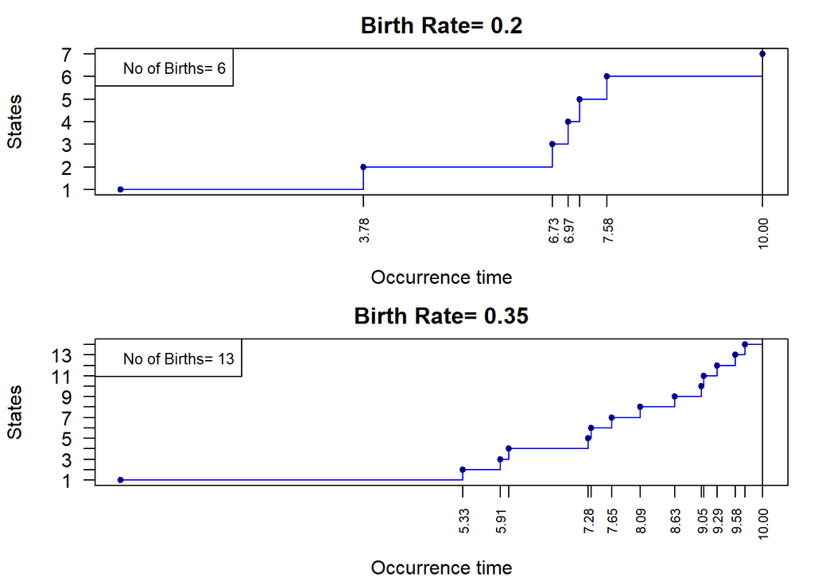

```r
par(mfrow=c(2,1), mar=c(4, 4, 2, 1) + 0.1)
rate=paste("Birth Rate=",la,sep=" ")
number=paste("No of Births=",N,sep=" ")
for(j in 1:length(la))
{
plot(v[[j]],u[[j]],"l",main=rate[j],ylab="States",
xlab="Occurrence time", yaxt="n",xaxt="n",col="blue")
axis(2,at=sort(unique(u[[j]])),labels=sort(unique(u[[j]])),
las=2)
axis(1,at=round(c(arr[[j]],t),2),las=2,cex.axis=0.7)
points(w[[j]],x[[j]],pch=20,col="dark blue")
abline(v=t)
legend("topleft",legend=number[j],cex=.8)
}
```

```r
par(mfrow=c(1,1), mar=c(5, 4, 4, 2) + 0.1)
```

Suppose ${X(t), t ≥ 0}$ is a Yule Furry process with birth rate $\lambda$ = 0.12 and X(0) = 1. With this code, we obtain 150 realizations of the process when it is observed for t = 10 time units and verify whether X(t ) follows a geometric distribution.

### Part I: Input birth rate, t and number of simulations

```r
lambda=.12; t=10; nsim=150
```

### Part II: Multiple simulations

```r
x=c() # population size at t
for(m in 1:nsim)
{
set.seed(m); y=c(); sumy=0; i=1
while(sumy<t)
{
y[i]=rexp(1,rate=i*lambda)
sumy=sum(y); i=i+1
}
l=length(y); l; y=y[-l]; x[m]=length(y)+1
}
x; mean(x);var(x); e=exp(1); p=e^(-lambda*t); mu=1/p;mu
```

```
##   [1]  2  1  1  2  1  9  3  3  1  6  2  1  3  6  3  3  1  7  1  7  4  2  4  2  1
##  [26]  1  3  1  1  1  8 12  3  1 12  6  2  1  2  4  1 10  2  5  3  1  6  2  2  4
##  [51]  2  1  2  8  4  1  1  2  1  3  3  4  3  1  1  6  9  6  8  1  3  8  4  9  1
##  [76]  7  3  6  5  2  1  1  1  4  4  5  1  1  1  5  7  1  2  3  1  6  1  2  2  2
## [101]  2  6  1  2  1  1  2  3  1  3  6  2  6  6  2  3  2  1  1  1  1  2  3  1  2
## [126]  3  2  5  1 10  1  6  5  1  2  2  5  2  4  8  3  9  3  1 11  1  7  1  2  1
```

```
## [1] 3.286667
```

```
## [1] 6.997808
```

```
## [1] 3.320117
```

```r
var=(1-p)/p^2; var
```

```
## [1] 7.703059
```

### Part III: Observed and expected distributions

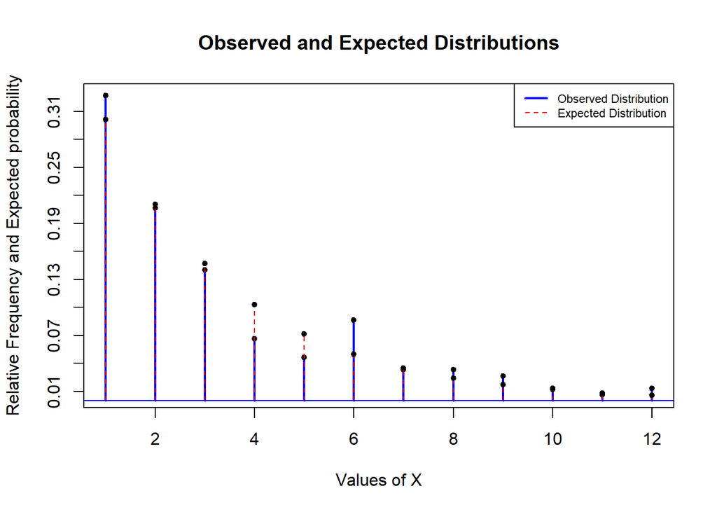

```r
d=data.frame(table(factor(x, levels=1:max(x))))
obf=d$Freq; N=sum(obf); rf=obf/N; t=sort(unique(x))
v=p*(1-p)^(t-1); ex=nsim*v; ex=round(ex,2);
a=min(min(rf),min(v));b=max(max(rf),max(v))
u=seq(round(a,2),b,.03)
plot(t,rf,"h",col="blue",lty=1,lwd=2,xlab="Values of X",
main="Observed and Expected Distributions",
ylim=range(c(a,b)),ylab="Relative Frequency and Expected probability",
yaxt="n")
axis(2,at=u); points(t,rf,pch=20)
lines(t,v,"h",col="red",lty=2,lwd=1)
points(t,v,pch=20)
abline(h=0, col="blue")
legend("topright",cex=.7,col=c("blue","red"),lty=c(1,2),
legend=c("Observed Distribution","Expected Distribution"),
lwd=c(2,1))
```

### Part IV: Goodness of fit test with pooling frequencies

```r
v1=1-sum(v); v2=c(v,v1); e=nsim*v2; length(e);ob=c(obf,0)
```

```
## [1] 13
```

```r
length(ob); y=c(t,"> 12"); da=round(data.frame(ob,e),2)
```

```
## [1] 13
```

```r
da1=data.frame(y,da);da1
```

```
##       y ob     e
## 1     1 49 45.18
## 2     2 31 31.57
## 3     3 21 22.06
## 4     4 10 15.42
## 5     5  7 10.77
## 6     6 13  7.53
## 7     7  5  5.26
## 8     8  5  3.68
## 9     9  4  2.57
## 10   10  2  1.80
## 11   11  1  1.25
## 12   12  2  0.88
## 13 > 12  0  2.03
```

```r
o1=c(ob[1:8],ob[9]+ob[10]+ob[11]+ob[12])
e1=c(e[1:8],e[9]+e[10]+e[11]+e[12])
t1=sum((o1-e1)^2/e1); t1;df=length(o1)-1;df
```

```
## [1] 9.040858
```

```
## [1] 8
```

```r
b1=qchisq(.95,df); b1; p1=1-pchisq(t1,df); p1
```

```
## [1] 15.50731
```

```
## [1] 0.3388609
```

### Part V: Goodness of fit test without pooling frequencies

```r
d=length(ob)-1; d
```

```
## [1] 12
```

```r
t=sum((ob-e)^2/e); t; b=qchisq(.95,d); b; p=1-pchisq(t,d); p
```

```
## [1] 12.42062
```

```
## [1] 21.02607
```

```
## [1] 0.4125169
```

### Part VI: Goodness of fit test with built-in function

```r
chisq.test(ob,p=v2)
```

```
##
##  Chi-squared test for given probabilities
##
## data:  ob
## X-squared = 12.421, df = 12, p-value = 0.4125
```

> fail to reject $h_0$

## Realization of a linear death process

We obtain a realization of a linear death process with death rate $\mu$ as 0.1 and 0.25 and X(0) = a = 20, when it is observed for t = 10 time units.

### Part I: Input death rates, X(0) and t

```r
mu=c(.1,.25); a=20; t=10
```

### Part II: Realizations

```r
int=x=arr=u=v=w=list(); N=c()
for(j in 1:length(mu))
{
set.seed(j); y=s=c();sumy=0; i=1;s[1]=a
while(sumy<t)
{
y[i]=rexp(1,rate=s[i]*mu[j])
s[i+1]=s[i]-1
if(s[i]==0){break}
else
sumy=sum(y); i=i+1
}
int[[j]]=y[-length(y)]
N[j]=length(int[[j]])
x[[j]]=s[-length(s)]
u[[j]]=rep(x[[j]],each=2)
arr[[j]]=round(cumsum(int[[j]]),2)
v[[j]]=c(0,round(rep(arr[[j]],each=2),3),t)
w[[j]]=c(0,arr[[j]])
}
# x;int;arr;u;v;w
N
```

```
## [1] 13 17
```

```r
list("States"=x,"Interval r.v."=int,"Death epochs"=arr)
```

```
## $States
## $States[[1]]
##  [1] 20 19 18 17 16 15 14 13 12 11 10  9  8  7
##
## $States[[2]]
##  [1] 20 19 18 17 16 15 14 13 12 11 10  9  8  7  6  5  4  3
##
##
## $`Interval r.v.`
## $`Interval r.v.`[[1]]
##  [1] 0.37759092 0.62191725 0.08094818 0.08223251 0.27254289 1.92997902
##  [7] 0.87825861 0.41514065 0.79713958 0.13367817 1.39073513 0.84669984
## [13] 1.54700444
##
## $`Interval r.v.`[[2]]
##  [1] 0.37307049 0.08521012 0.03258948 0.40722582 0.02238155 0.17783937
##  [7] 0.30696196 0.46511671 0.43809197 0.05692010 0.29804758 0.55259793
## [13] 0.33688918 0.90874622 0.72149078 0.63727778 1.44527039
##
##
## $`Death epochs`
## $`Death epochs`[[1]]
##  [1] 0.38 1.00 1.08 1.16 1.44 3.37 4.24 4.66 5.46 5.59 6.98 7.83 9.37
##
## $`Death epochs`[[2]]
##  [1] 0.37 0.46 0.49 0.90 0.92 1.10 1.41 1.87 2.31 2.37 2.66 3.22 3.55 4.46 5.18
## [16] 5.82 7.27
```

### Part III: Graphs of realizations

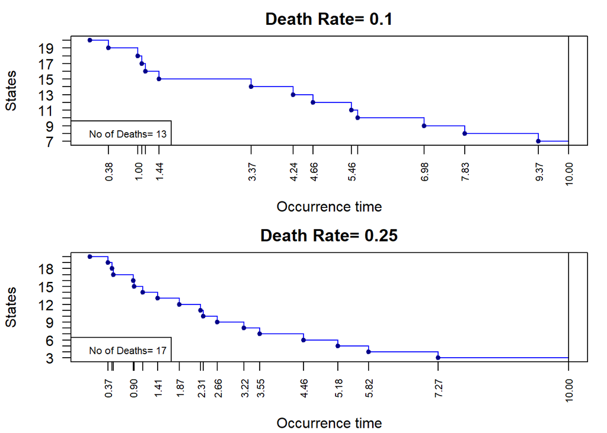

```r
par(mfrow=c(2,1), mar=c(4, 4, 2, 1) + 0.1)
rate=paste("Death Rate=",mu,sep=" ")
number=paste("No of Deaths=",N,sep=" ")
for(j in 1:length(mu))
{
plot(v[[j]],u[[j]],"l",main=rate[j],ylab="States",
xlab="Occurrence time",yaxt="n",xaxt="n",col="blue")
axis(2,at=sort(unique(u[[j]])),labels=sort(unique(u[[j]])),
las=2)
axis(1,at=round(c(arr[[j]],t),2),las=2,cex.axis=0.7)
points(w[[j]],x[[j]],pch=20,col="dark blue")
abline(v=t)
legend("bottomleft",legend=number[j],cex=.7)
}
```

```r
par(mfrow=c(1,1), mar=c(5, 4, 4, 2) + 0.1)
```

## Multiple Realization of a linear death process

We obtain 200 realizations of a linear death process with death rate $\mu = 0.12$ and X(0) = 10, when it is observed for t = 12 time units and verify whether X(t ) follows the binomial $B(10, e^{−μt} )$ distribution.

### Part I: Input death rate, X(0),t and number of simulations

```r
mu=.12; nsim=200; t=12; ini=10 # X(0)
```

### Part II: Multiple realizations

```r
y=s=x=c();
for(m in 1:nsim)
{
set.seed(m); sumy=0; s[1]=ini; i=1
while(sumy<t)
{
y[i]=rexp(1,rate=s[i]*mu)
s[i+1]=s[i]-1
if(s[i]==0){break}
else
sumy=sum(y); i=i+1
}
l=length(y); y=y[-l]; x[m]=ini-length(y)
}
mean(x);var(x); e=exp(1);p=e^(-mu*t);p
```

```
## [1] 2.55
```

```
## [1] 1.886935
```

```
## [1] 0.2369278
```

```r
mu1=ini*p;mu1; var=ini*p*(1-p);var
```

```
## [1] 2.369278
```

```
## [1] 1.80793
```

```r
d=data.frame(table(factor(x, levels=0:max(x))));d
```

```
##   Var1 Freq
## 1    0    9
## 2    1   39
## 3    2   52
## 4    3   55
## 5    4   30
## 6    5    9
## 7    6    5
## 8    7    1
```

### Part III: Observed and expected distributions

```r
obf=d$Freq; N=sum(obf); rf=obf/N;rf
```

```
## [1] 0.045 0.195 0.260 0.275 0.150 0.045 0.025 0.005
```

```r
ob=c(obf,0,0,0); r=0:ini; rf1=c(rf,0,0,0)
pr=dbinom(r,size=ini,prob=p);sum(pr)
```

```
## [1] 1
```

```r
ex=nsim*pr; ex=round(ex,2);ex;
```

```
##  [1] 13.39 41.57 58.08 48.09 26.13  9.74  2.52  0.45  0.05  0.00  0.00
```

```r
da=data.frame(r,ob,ex);da
```

```
##     r ob    ex
## 1   0  9 13.39
## 2   1 39 41.57
## 3   2 52 58.08
## 4   3 55 48.09
## 5   4 30 26.13
## 6   5  9  9.74
## 7   6  5  2.52
## 8   7  1  0.45
## 9   8  0  0.05
## 10  9  0  0.00
## 11 10  0  0.00
```

```r
a=min(min(rf1),min(pr));b=max(max(rf1),max(pr))
u=seq(round(a,2),b,.03);u
```

```
##  [1] 0.00 0.03 0.06 0.09 0.12 0.15 0.18 0.21 0.24 0.27
```

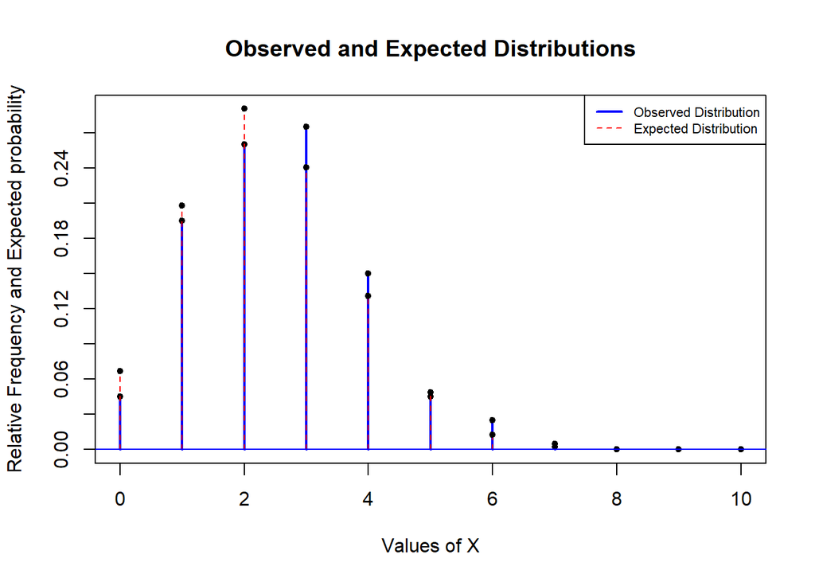

```r
plot(r,rf1,"h",col="blue",lty=1,lwd=2,xlab="Values of X",
main="Observed and Expected Distributions",ylim=range(c(a,b)),
ylab="Relative Frequency and Expected probability",yaxt="n")
axis(2,at=u); points(r,rf1,pch=20)
lines(r,pr,"h",col="red",lty=2,lwd=1)
points(r,pr,pch=20)
abline(h=0, col="blue")
legend("topright",cex=.7,col=c("blue","red"),lty=c(1,2),
legend=c("Observed Distribution","Expected Distribution"),
lwd=c(2,1))
```

### Part IV: Goodness of fit test, with pooling the frequencies

```r
e=nsim*pr;e; o1=c(obf[1:6],obf[7]+obf[8])
```

```
##  [1] 1.338710e+01 4.156587e+01 5.807639e+01 4.808600e+01 2.612805e+01
##  [6] 9.735058e+00 2.518881e+00 4.469098e-01 5.203570e-02 3.590370e-03
## [11] 1.114781e-04
```

```r
e1=c(e[1:6],e[7]+e[8]+e[9]+e[10]+e[11]); e1
```

```
## [1] 13.387101 41.565867 58.076394 48.086002 26.128050  9.735058  3.021528
```

```r
t1=sum((o1-e1)^2/e1); t1;df=length(o1)-1;df
```

```
## [1] 6.791294
```

```
## [1] 6
```

```r
b1=qchisq(.95,df); b1; p1=1-pchisq(t1,df); p1
```

```
## [1] 12.59159
```

```
## [1] 0.3405803
```

### Part V: Goodness of fit test, without pooling the frequencies

```r
ob=c(obf,0,0,0);df1=length(ob)-1; df1
```

```
## [1] 10
```

```r
t=sum((ob-e)^2/e); t; b2=qchisq(.95,df1); b2
```

```
## [1] 7.039424
```

```
## [1] 18.30704
```

```r
p2=1-pchisq(t,df1); p2
```

```
## [1] 0.7217179
```

### Part VI: Goodness of fit test, with built-in function

```r
chisq.test(ob,p=pr)
```

```
##
##  Chi-squared test for given probabilities
##
## data:  ob
## X-squared = 7.0394, df = 10, p-value = 0.7217
```

```r
fisher.test(ob, pr)
```

```
##
##  Fisher's Exact Test for Count Data
##
## data:  ob and pr
## p-value = 1
## alternative hypothesis: two.sided
```

## Realization of a linear birth-death process

We obtain the realization of a linear birth-death process with birth rate $\lambda$, death rate $\mu$ and X(0) = 10, for a fixed time interval (0, 10]. For comparison we take two sets of birth and death rates as $\lambda = 0.12$, $\mu = 0.1$ and $\lambda = 0.1$, $\mu = 0.4$

### Part I: Input birth and death rates, X(0) and t

```r
la=c(0.12,0.1); mu=c(0.1,0.4); a=10; t=10
```

### Part II: Realizations

```r
P=matrix(c(mu[1]/(la[1]+mu[1]),la[1]/(la[1]+mu[1]),
mu[2]/(la[2]+mu[2]),la[2]/(la[2]+mu[2])), ncol=2,byrow=TRUE)
P # tpm of embedded Markov chain
```

```
##           [,1]      [,2]
## [1,] 0.4545455 0.5454545
## [2,] 0.8000000 0.2000000
```

```r
S=c(-1,1); int=x=arr=u=v=w=list(); N=c()
for(j in 1:length(mu))
{
set.seed(j)
y=s=c();sumy=0; i=1;s[1]=a
while(sumy<t)
{
y[i]=rexp(1,rate=s[i]*(la[j]+mu[j]))
s[i+1]=s[i]+sample(S,1,P[,j],replace=t)
if(s[i]==0){break}
else
sumy=sum(y); i=i+1
}
int[[j]]=y[-length(y)]
N[j]=length(int[[j]])
x[[j]]=s[-length(s)]
u[[j]]=rep(x[[j]],each=2)
arr[[j]]=round(cumsum(int[[j]]),2)
v[[j]]=c(0,round(rep(arr[[j]],each=2),3),t)
w[[j]]=c(0,arr[[j]])
}
N
```

```
## [1] 30 24
```

```r
list("States"=x,"Interval r.v."=int,"epochs"=arr)
```

```
## $States
## $States[[1]]
##  [1] 10 11 10  9 10 11 12 13 12 11 12 13 14 15 14 15 16 15 16 15 16 15 16 17 18
## [26] 19 20 21 20 19 20
##
## $States[[2]]
##  [1] 10  9  8  9  8  7  8  7  8  7  6  5  6  5  4  3  4  5  4  3  2  3  4  3  2
##
##
## $`Interval r.v.`
## $`Interval r.v.`[[1]]
##  [1] 0.34326447 0.06020939 0.90897719 0.22023668 0.92458680 0.15456434
##  [7] 0.20442532 0.15218078 0.45957875 0.06076281 0.28864767 1.54683015
## [13] 0.33611816 0.19840807 0.19106484 0.13558239 0.18235585 0.17147440
## [19] 0.01688613 1.19967662 0.13199644 0.30206453 0.62792792 0.25621230
## [25] 0.08182075 0.04868669 0.06857749 0.16267158 0.23850885 0.25834477
##
## $`Interval r.v.`[[2]]
##  [1] 0.373070488 0.032589482 0.022381545 0.238748191 0.130256657 0.375507402
##  [7] 0.012992944 0.355241529 0.397576472 0.227599207 1.497314112 0.248153716
## [13] 0.009521175 0.275543202 0.167225648 0.053180135 0.294863824 0.435800329
## [19] 0.310397263 3.088388159 0.623719391 0.283706486 0.125121730 0.179360963
##
##
## $epochs
## $epochs[[1]]
##  [1] 0.34 0.40 1.31 1.53 2.46 2.61 2.82 2.97 3.43 3.49 3.78 5.32 5.66 5.86 6.05
## [16] 6.19 6.37 6.54 6.56 7.76 7.89 8.19 8.82 9.07 9.16 9.20 9.27 9.44 9.67 9.93
##
## $epochs[[2]]
##  [1] 0.37 0.41 0.43 0.67 0.80 1.17 1.19 1.54 1.94 2.17 3.66 3.91 3.92 4.20 4.36
## [16] 4.42 4.71 5.15 5.46 8.55 9.17 9.45 9.58 9.76
```

### Part III: Graphs of realizations

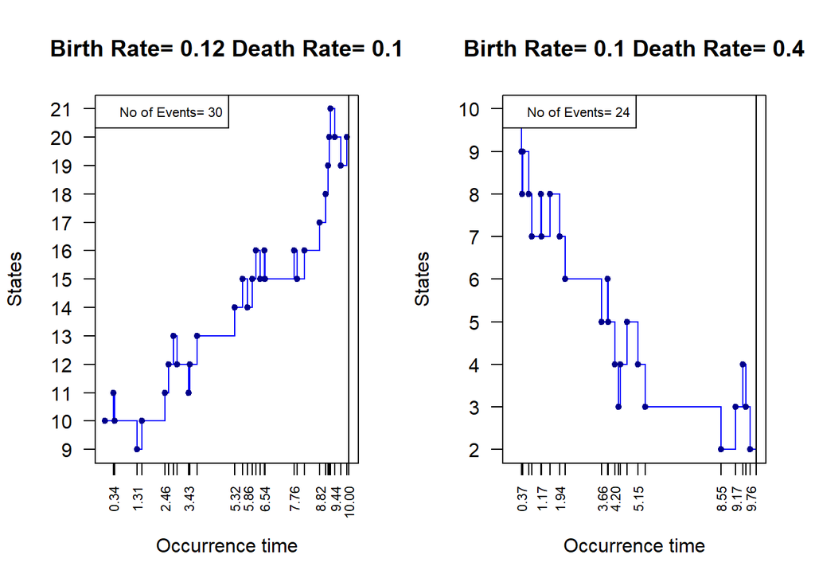

```r
par(mfrow=c(1,2))
rate=paste("Birth Rate=",la,"Death Rate=",mu,sep=" ")
number=paste("No of Events=",N,sep=" ")
for(j in 1:length(mu))
{
plot(v[[j]],u[[j]],"l",main=rate[j],ylab="States",
xlab="Occurrence time",yaxt="n",xaxt="n",col="blue")
axis(2,at=sort(unique(u[[j]])),labels=sort(unique(u[[j]])),
las=2)
axis(1,at=round(c(arr[[j]],t),2),las=2,cex.axis=0.7)
points(w[[j]],x[[j]],pch=20,col="dark blue")
abline(v=t)
legend("topleft",legend=number[j],cex=.7,col="red")
}
```